# Lancet padded vs unpadded

C. Savonen for ALSF CCDL

2020

#### Purpose:

This analysis resulted from an [idea in a comment here](https://github.com/AlexsLemonade/OpenPBTA-analysis/pull/548#issuecomment-589734993). In short we were seeing particularly low VAF for Lancet TCGA data and were wondering whether this had to do with the extra padding allowed in the pipeline (to try to account for its local assembly).

### Conclusion:

Lancet was doing poorly with WXS samples, whether or not they were using SNVs in the padding regions of the BED.

Declare names of input and output directories.

```r
# magrittr pipe
`%>%` <- dplyr::`%>%`

data_dir <- file.path("..", "..", "..", "data")
scratch_dir <- file.path("..", "..", "..", "scratch")

# Load in these functions so we can use `maf_to_granges`
source(file.path("..", "..", "snv-callers", "util", "tmb_functions.R"))
```

Load in the WXS ranges for Lancet data included with the data release.

```r
wxs_padded <- readr::read_tsv(file.path(data_dir, "WXS.hg38.lancet.400bp_padded.bed"),
  col_names = FALSE
)
```

Set up this data as a GenomicRanges object.

```r
# Turn the bed regions df into a GRanges object
padded_ranges <- GenomicRanges::GRanges(
  seqnames = wxs_padded$X1,
  ranges = IRanges::IRanges(
    start = wxs_padded$X2,
    end = wxs_padded$X3
  )
)
```

Set up an alternative form of this data with the padding on either side removed.

```r
# Turn the bed regions df into a GRanges object
unpadded_ranges <- GenomicRanges::GRanges(
  seqnames = wxs_padded$X1,
  ranges = IRanges::IRanges(
    start = wxs_padded$X2 + 400,
    end = wxs_padded$X3 - 400
  )
)
```

Connect to SQLite database.

```r
# Start up connection
con <- DBI::dbConnect(
  RSQLite::SQLite(),
  file.path(scratch_dir, "v11_snv_db.sqlite")
)
```

Note what columns we will join by.

```r
cols_to_keep <- c(
  "Chromosome",
  "Start_Position",
  "End_Position",
  "Reference_Allele",
  "Allele",
  "Tumor_Sample_Barcode",
  "Variant_Classification",
  "VAF"
)
```

Set up the Lancet data from the SQL database.

```r
lancet <- dplyr::tbl(con, "lancet") %>%
  dplyr::select(cols_to_keep) %>%
  dplyr::inner_join(
    dplyr::tbl(con, "samples") %>%
      dplyr::select(
        Tumor_Sample_Barcode = Kids_First_Biospecimen_ID,
        experimental_strategy, short_histology
      )
  ) %>%
  as.data.frame()
```

Get this data split into WXS only and WGS only data frames.

```r
wxs_lancet <- lancet %>%
  dplyr::filter(experimental_strategy == "WXS")

wgs_lancet <- lancet %>%
  dplyr::filter(experimental_strategy == "WGS")
```

We will need to filter VAF data out by whether it is in the unpadded or padded ranges. So let’s turn only the WXS data into a GenomicRanges object.

```r
# Turn the MAF sample mutations into a GRanges object
wxs_lancet_granges <- maf_to_granges(wxs_lancet)
```

Now we’ll find the overlaps with the unpadded ranges and keep only those SNVs.

```r
overlap <- GenomicRanges::findOverlaps(
  wxs_lancet_granges,
  unpadded_ranges
)

unpadded_lancet <- wxs_lancet[unique(overlap@from), ]
```

Do the same thing but for the padded ranges.

```r
overlap <- GenomicRanges::findOverlaps(
  wxs_lancet_granges,
  padded_ranges
)

padded_lancet <- wxs_lancet[unique(overlap@from), ]
```

Combine the unpadded, padded, and the WGS data for Lancet into one big data.frame where the “pad” variable says where the data is from.

```r
lancet_combo <- dplyr::bind_rows(list(
  wxs_padded = padded_lancet,
  wxs_unpadded = unpadded_lancet,
  wgs = wgs_lancet
), .id = "pad")
```

Plot this data as a violin plot.

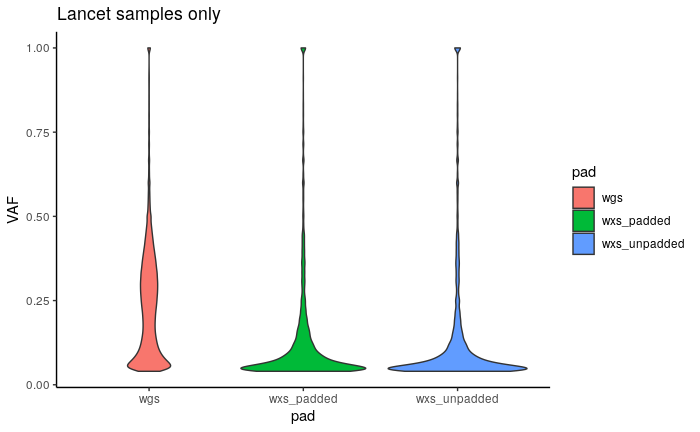

```r
ggplot2::ggplot(lancet_combo, ggplot2::aes(x = pad, y = VAF, fill = pad)) +
  ggplot2::geom_violin() +
  ggplot2::theme_classic() +
  ggplot2::ggtitle("Lancet samples only")
```